# Green House Gas Emissions Visualization Component_1 Name:- P Keshavan Rollno:- MDS202223

### Abstract

The report’s objective is to comprehend greenhouse gas emissions using a variety of visualizations.We looked at three primary greenhouse gases: carbon dioxide (CO<sub>2</sub>), nitrogen oxide (N<sub>2</sub>O), and methane (CH<sub>4</sub>).Chloropleths, bar graphs, and Box plots are used for each gas to identify and assess world emissions, followed by the distribution of emissions across various sectors using a donut chart, and lastly a trend line enumerating how emissions have fared over the past three decades. Similar methods are used to analyse the overall emissions of greenhouse gases. A comparison analysis is performed among China, India and USA across various gases employing grouped trend line.

### Introduction

Climate change is one of the most pressing issues that is concerning humanity today and its seriousness is growing by the day. Climate change refers to the change in earth’s climatic conditions and patterns. This process is steady and natural, but anthropogenic activities have made it uneven and, in many cases, accelerated. Global warming is one such process.Global warming is often associated with a runaway “greenhouse effect.” The greenhouse effect describes the process of certain gases (including carbon dioxide (CO2), methane, nitrous oxide (N2O), fluorinated gases, and ozone) trapping solar radiation in a planet’s lower atmosphere. Greenhouse gases let the sun’s light shine onto Earth’s surface, but they trap the heat that reflects back up into the atmosphere. In this way, they act like the glass walls of a greenhouse.The greenhouse effect is a natural phenomenon and keeps Earth warm enough to sustain life. However, human activities that include burning fossil fuels and cutting down forests release greenhouse gases into the atmosphere at an unprecedented rate.Increasing temperatures can change the climate impacts and even the classification of a region.

Recognizing the urgency of the situation, world leaders convened in Rio de Janeiro in 1992 (Earth Summit) and agreed to work together to combat climate change.An important achievement of the summit was an agreement on the Climate Change Convention which in turn led to the Kyoto Protocol and the famous Paris Agreement(2015). A tremendous amount of research is being done on the causes and the effects of climate change. Enormous amount of data is collected from various sources such as government agencies, NGO etc. to understand these situations better. These problems are now being studied and simulated using advanced scientific methods such as machine learning and artificial intelligence (Earth Simulator supercomputer).

### Dataset Description

Climate Watch is an online platform designed to empower policymakers, researchers, media and other stakeholders with the open climate data, visualizations and resources they need to gather insights on national and global progress on climate change. Climate Watch brings together dozens of datasets for the first time to let users analyze and compare the Nationally Determined Contributions (NDCs) under the Paris Agreement, access historical emissions data, discover how countries can leverage their climate goals to achieve their sustainable development objectives and use models to map new pathways to a lower carbon, prosperous future.(Climate Watch Historical GHG Emissions. 2022. Washington, DC: World Resources Institute. https://www.climatewatchdata.org/ghg-emissions)

The data being used is Climate Watch Historical Emissions data which contains sector-level greenhouse gas (GHG) emissions data for 194 countries and the European Union for the period 1990-2019, including emissions of the six major GHGs from most major sources and sinks. Non-CO2 emissions are expressed in CO2 equivalents using 100-year global warming potential values from the IPCC Fourth Assessment Report. I will be using Historical emission data from Climate Analysis Indicators Tool (CAIT) data source. The following are the columns of the data

1. **Country**: 194 country names (This includes the country=“world”)
2. **Data Source**: Climate Analysis Indicators Tool (CAIT) (Same for all the rows)
3. **Sector**: The following sectors are included:-
   - **Energy**: This sector includes
     - **Electricity/Heat**
     - **Manufacturing/Construction**
     - **Transportation**
     - **Fugitive Emissions**( leaks and other irregular releases of gases )
     - **Other Fuel Combustion**
   - **Waste**(emission due to decomposition of waste)
   - **Agriculture**
   - **Bunker Fuels**(Fuel used in ships)
   - **Industrial Processes**
   - **Land-use Change and Forestry (LUCF)**
   - **Building**

LUCF can act as source and a sink for GHG gases. Hence unlike other sectors LUCF can take both positive and negative values.Based on this, there are two totals that can be calculated i.e **Total including LUCF** and **Total excluding LUCF** (Both of these are included in the Sector Column).Hence Column Sector can considered a Categorical variable

4. **Gas**: The following GHG gases are included:-
   - **All GHG**
   - **CO2**
   - **N2O**
   - **CH4**
   - **(fluorinated) F-Gas**

   This is a categorical variable
5. **Units**: MtCO<sub>2</sub>e (Million tons CO<sub>2</sub> equivalent)(same for all the rows)
6. **Emission data (1990-2019)** (Next 30 Columns)(Positive and Negative numerical variable)

For Example: This is the 154<sup>th</sup> row.It shows how much amount of CH<sub>4</sub> in MtCO<sub>2</sub>e units is emitted due to Agricultural reasons in China for the years 1990 to 2019

```
##     Country Data.source      Sector Gas     Unit  X2019  X2018  X2017  X2016
## 154   China        CAIT Agriculture CH4 MtCOâ‚‚e 319.73 329.75 335.87 342.25
##      X2015  X2014  X2013  X2012  X2011  X2010  X2009  X2008 X2007  X2006  X2005
## 154 341.38 337.91 337.58 338.53 341.02 346.06 348.44 350.41 345.7 354.81 356.42
##      X2004  X2003  X2002  X2001  X2000  X1999  X1998  X1997  X1996  X1995
## 154 353.35 344.47 353.36 362.55 372.89 373.88 366.92 349.74 386.77 366.27
##      X1994  X1993  X1992  X1991  X1990
## 154 346.38 338.76 341.33 341.21 336.95
```

### Visualizations and Analysis

#### 1. Green House Gases Emission Globally

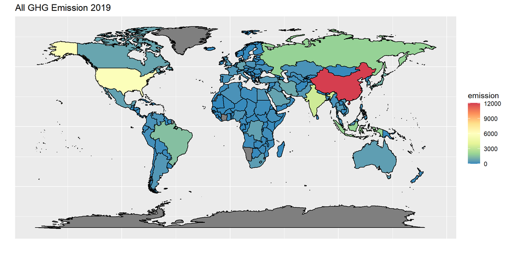

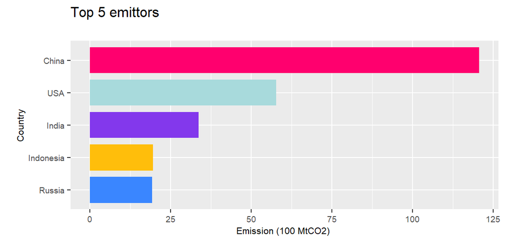

The chloropleth and bar graph are calculated using Total including LUCF emissions for the year 2019. From the chloropleth and the bar graph, it is clear that China, the USA, and India are among the highest emitters of GHG in the year 2019. To better understand the GHG emissions, we need to group the countries together (based on continent) and look at them individually. We remove China, India, and the USA (outliers) and then analyse the rest of the countries.

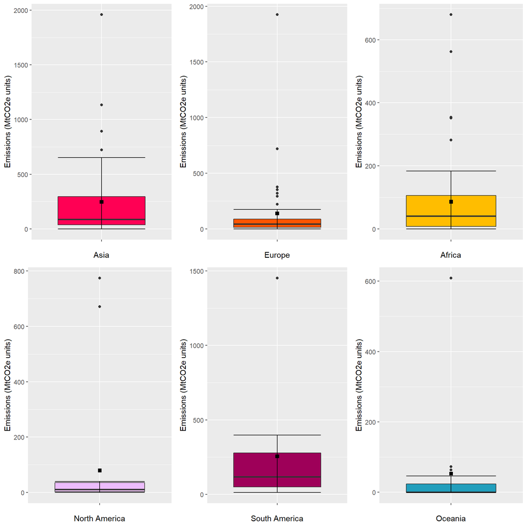

The donut chart below gives the sector wise distribution of GHG emissions of the world for the year 2019. The energy sector (Electricity/Heat, Manufacturing/Construction, Transportation,Fugitive Emissions, Other Fuel Combustion) is responsible for the maximum release of GHG. In the energy sector, the production of electricity is the largest emitter. In the non-energy sector, Agriculture sector is the largest emitter.

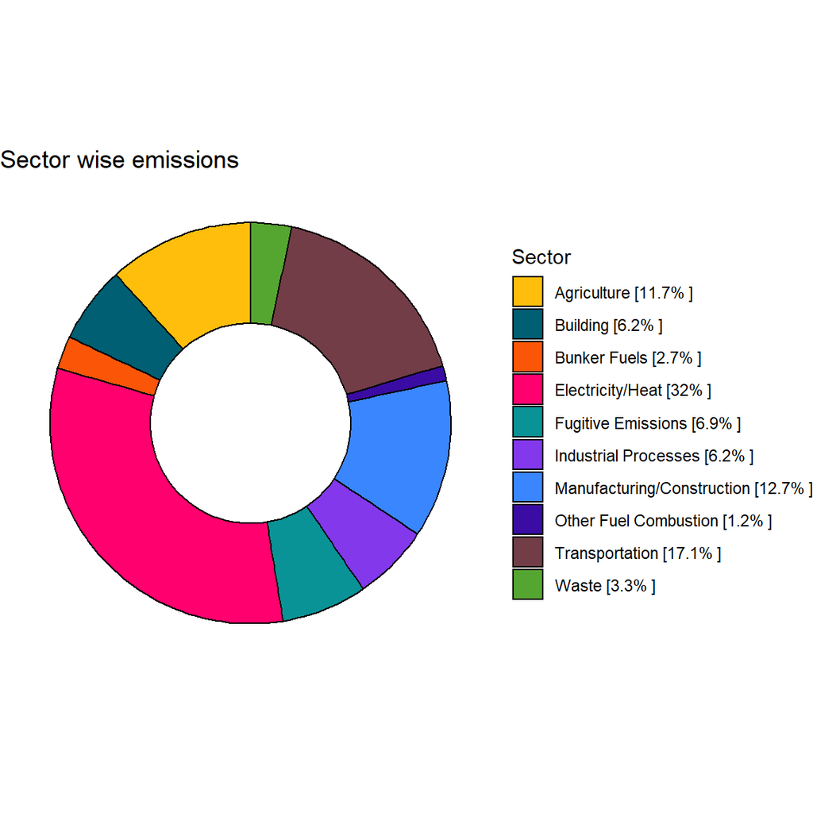

The following graphs show the historic emissions of GHG gases from 1990 to 2019. We can see that between 2000 and 2010, the emission increased from approximately 35000 to approximately 45000, whereas between 2010 and 2019, it has increased only by 5000. Overall, there has been a gradual increase in the emission of GHG over the past 30 years.

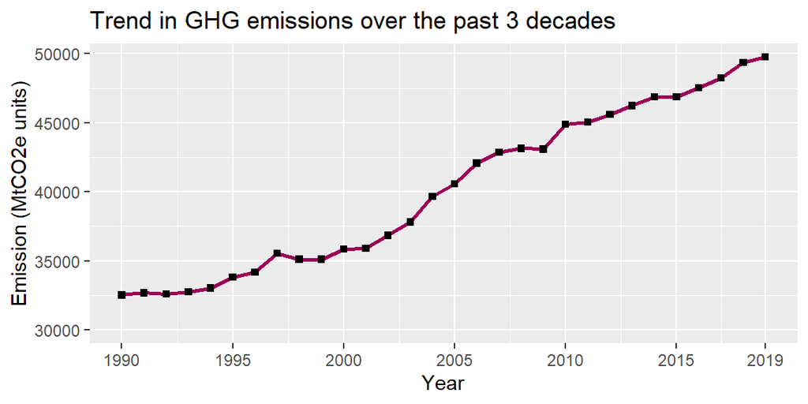

#### 2. CO<sub>2</sub> Emission Globally

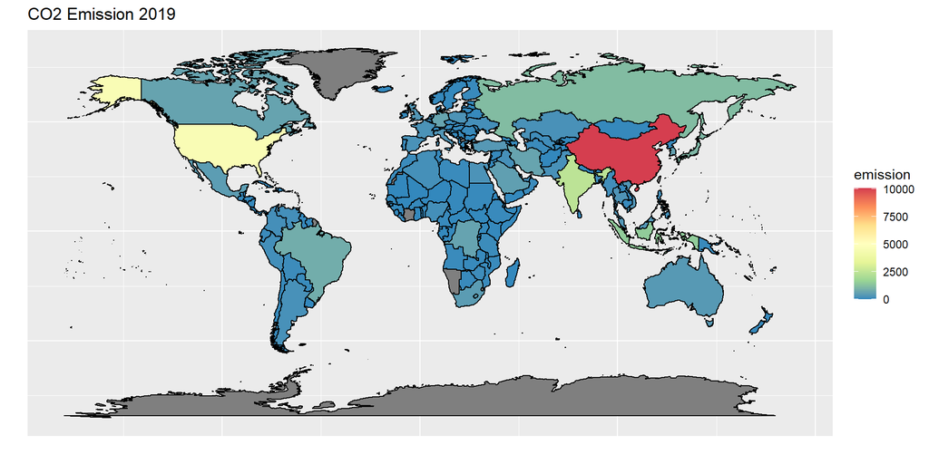

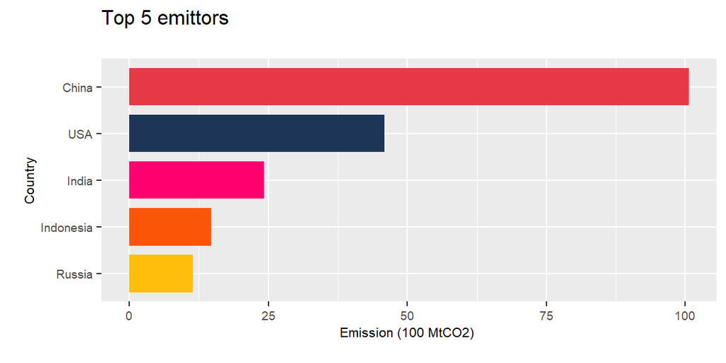

The chloropleth and bar graph are calculated using total including LUCF emissions of CO<sub>2</sub> for the year 2019. From the Chloropleth and the bar graph, it is clear that China, the USA, and India are among the highest emitters of CO<sub>2</sub> in the year 2019. To better understand the GHG emissions, we need to group the countries together (based on continent) and look at them individually. We remove China, India, and the USA (outliers) and then analyse the rest of the countries.

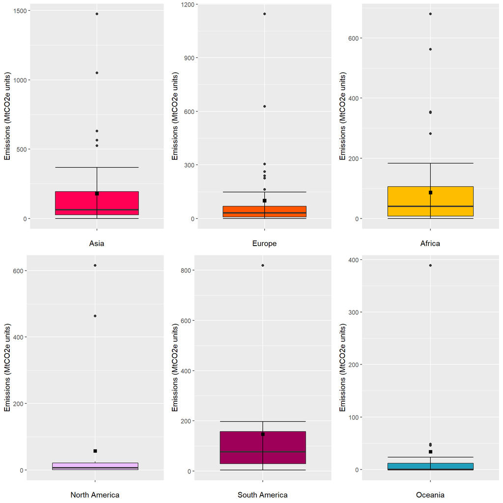

From the above box plots, we can say that the average CO<sub>2</sub> emission is below 250 MtCO<sub>2</sub>e units for each continent. The mean is higher compared to the median (each continent has a couple of outliers pulling the mean up). The median emission is less than 100 MtCO<sub>2</sub>e units (in 2 continents, close to zero). We can infer from this that only a couple of countries are responsible for high emissions in each continent. Globally, these outlier countries and the big three are responsible for the majority of the emissions. This fact is visible from the chloropleth.

The donut chart below gives the sector wise distribution of CO<sub>2</sub> emissions around the world for the year 2019. Energy Sector (Electricity/Heat, Manufacturing/Construction, Transportation,Fugitive Emissions, Other Fuel Combustion) is responsible for the maximum release of GHG. In Energy sector, production of electricity sector is the maximum emitter.In the non-energy sector, Building sector is the maximum emitter.

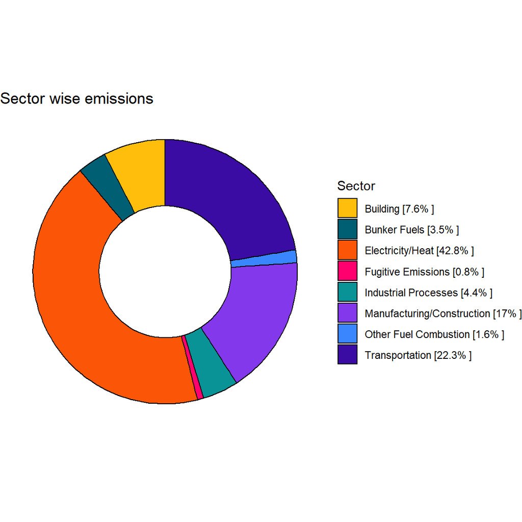

The following graphs show the historic emmission of CO<sub>2</sub> from 1990 to 2019. We can see that between 2000 and 2010, the emission increased from approximately 26000 to approximately 33000, whereas between 2010 and 2019, it increased only from 33000 to 37000. Overall, there has been a gradual increase in the emission of GHG over the past 30 years.

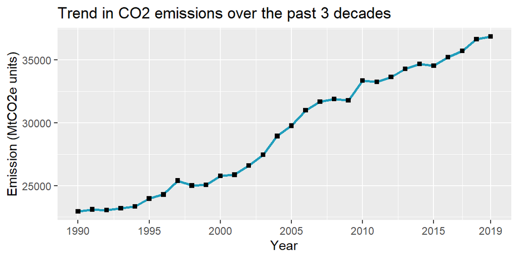

#### 3. N<sub>2</sub>O Emission Globally

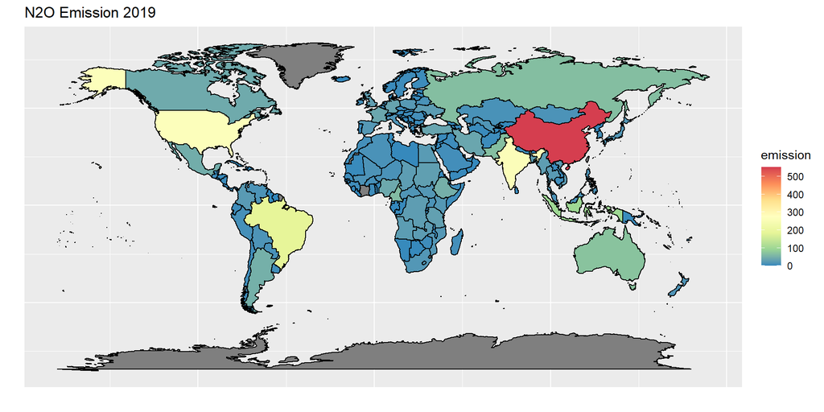

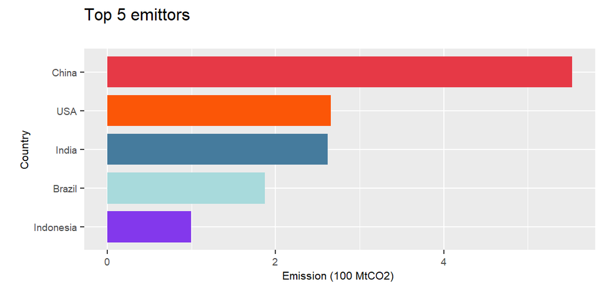

The chloropleth and bar graph are calculated using Total including LUCF emissions of N<sub>2</sub>O for the year 2019. From the chloropleth and the bar graph, it is clear that China, the USA, India, and Brazil are among the highest emitters of N<sub>2</sub>O in the year 2019. To better understand the GHG emissions, we need to group the countries together (based on continent) and look at them individually. We remove China, India, and the USA (outliers) and then analyse the rest of the countries.

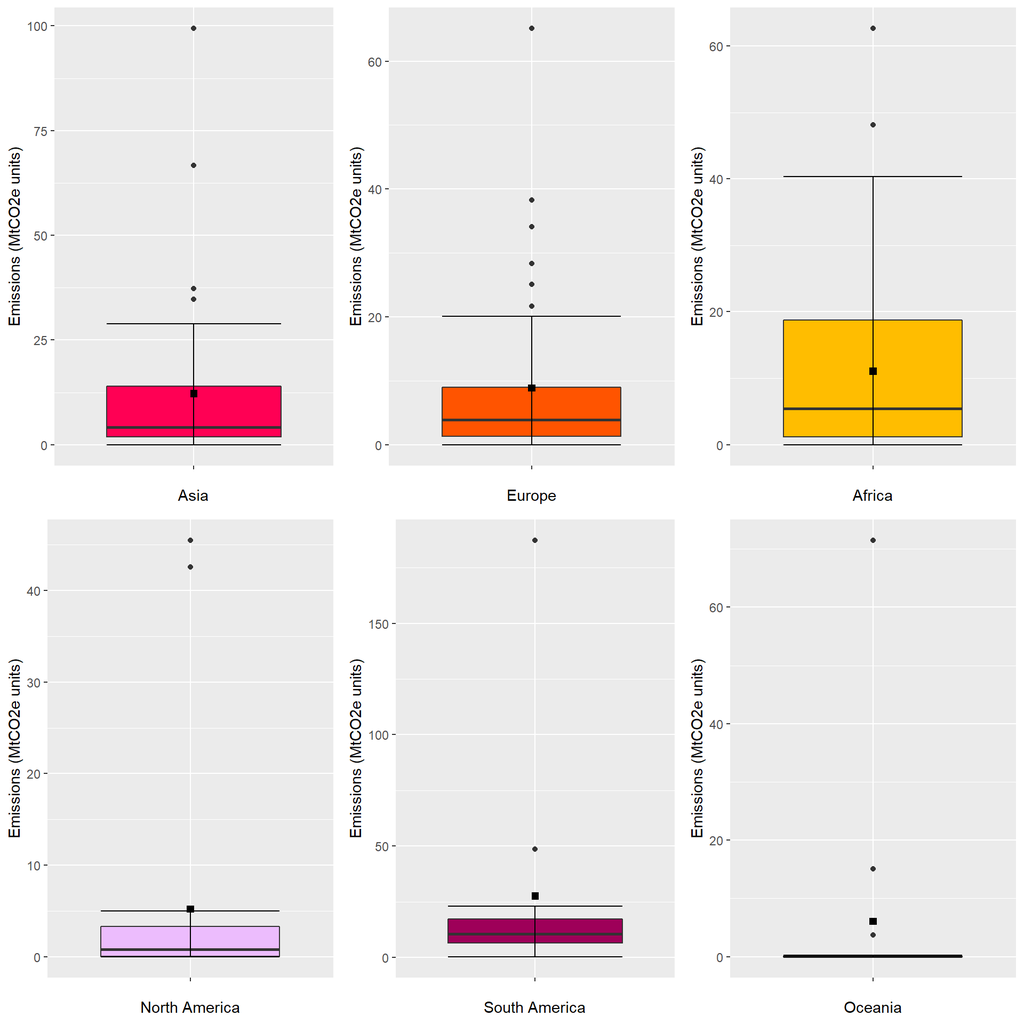

The donut chart below gives the sector wise distribution of GHG emissions around the world for the year 2019. Agriculture sector is responsible for the maximum amount of N<sub>2</sub>O emissions, followed by the industrial sector. This is due to the use of excess nitrogen-based fertilisers in agriculture.

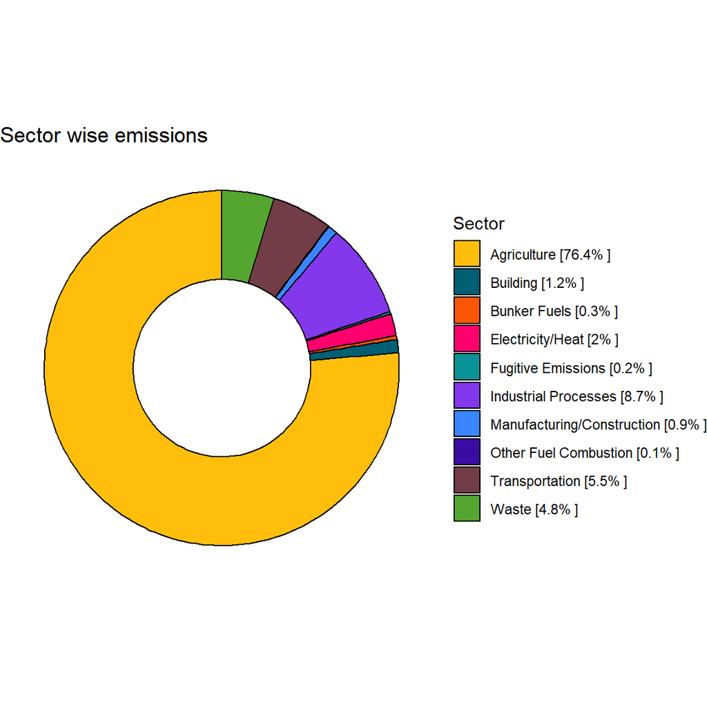

The following graphs show the historic emission of N<sub>2</sub>O gas from 1990 to 2019. Overall, there has been a gradual increase in the emission of N<sub>2</sub>O gas over the past 30 years (there are periods where emissions are increasing and periods where it is decreasing).

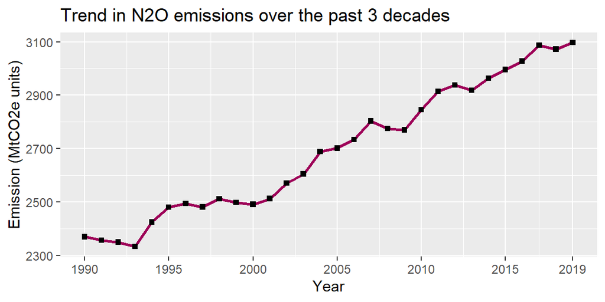

#### 4. CH<sub>4</sub> Emission Globally

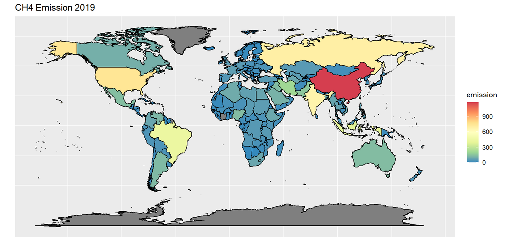

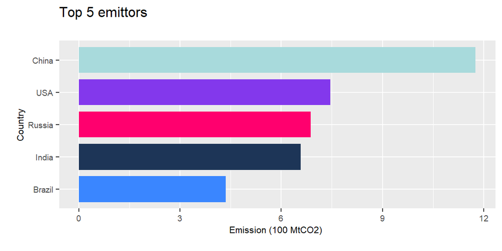

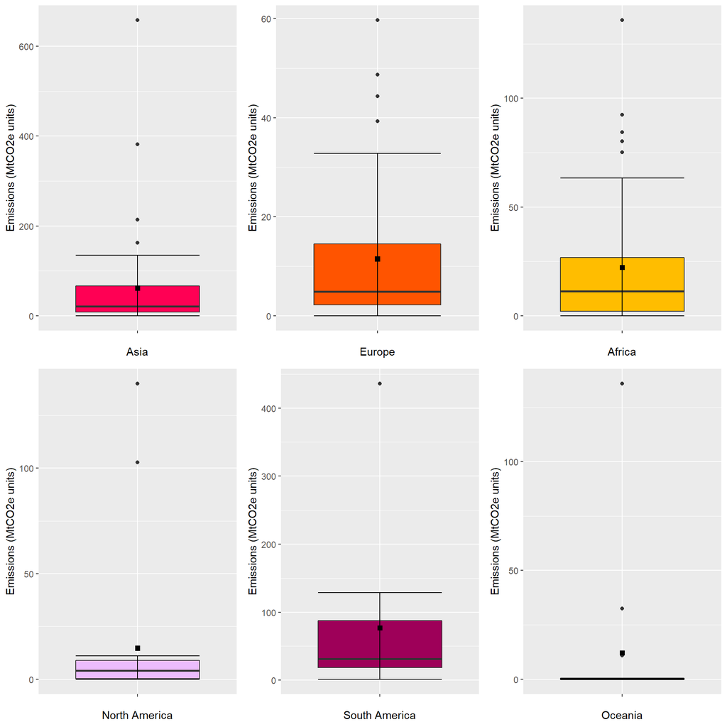

From the above box plots, we can say that the average CH<sub>4</sub> emission is below 100 MtCO<sub>2</sub>e units. The mean is higher compared to the median (each continent has a couple of outliers pulling the mean up). The median emission is less than 50 MtCO<sub>2</sub>e units (in Oceania, it is very close to zero). .We can infer from this that only a couple of countries are responsible for high emissions in each continent. Globally, these outlier countries and the big four(China, USA,Russia, and, India) are responsiblefor ther majority of the emissions. This fact is visible from the chloropleth.

The donut chart below gives the sector wise distribution of CH<sub>4</sub> emission of the world for the year 2019. Agriculture sector and Fugitive emission is responsible for the maximum amount of CH<sub>4</sub> emission.

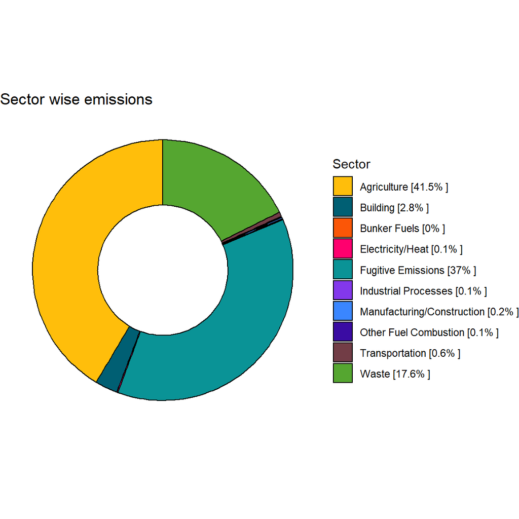

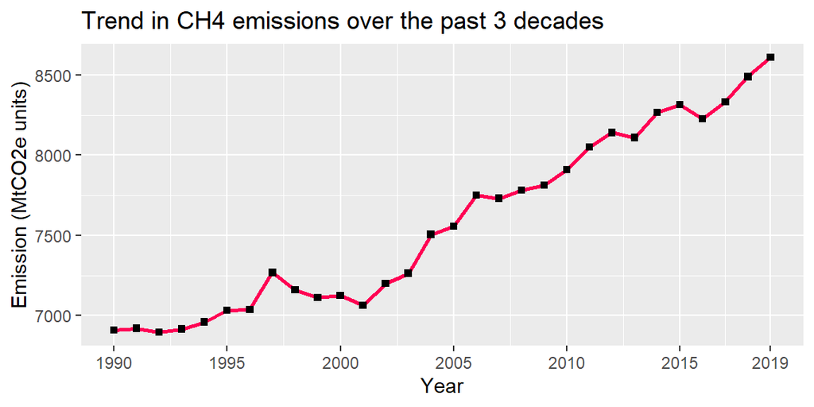

#### 5. Comparison Between China, India, USA

##### a. Comparing Total (including LUCF) GHG Emissions

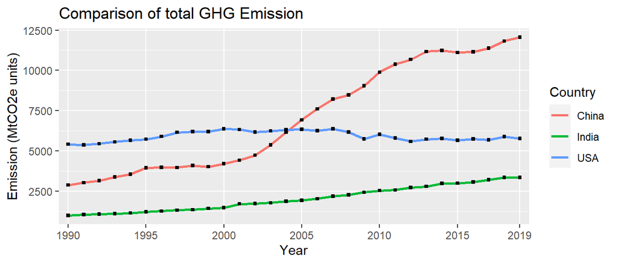

##### b. Comparing CO<sub>2</sub> Emissions

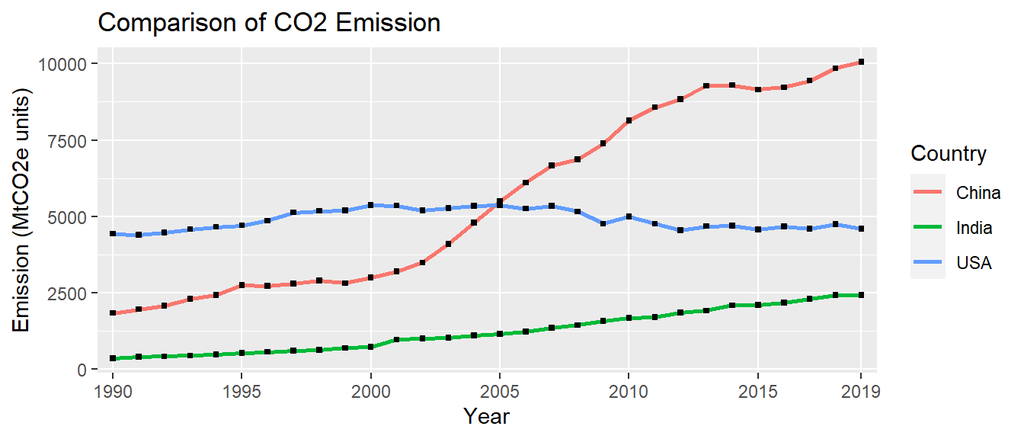

##### c. Comparing N<sub>2</sub>O Emissions

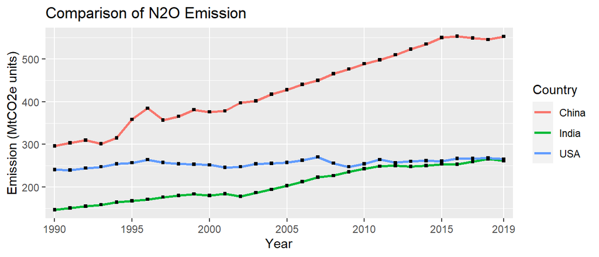

##### d. Comparing CH<sub>4</sub> Emissions

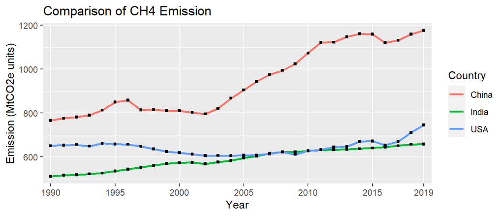

China has experienced the biggest increase in emissions of the three countries. China’s total GHG emissions have risen from 3000 MtCO2e in 1990 to almost 12000 MtCO2e in 2019. The graph (Total GHG emissions and CO2 emissions) illustrates that in 2004–2005, the then-leader, the United States, was surpassed by China (current leader). India’s emissions are gradually growing, whereas the United States has maintained the same level of emissions for the past 30 years (with a slight increase in CHsub>4/sub> emissions). We can plainly see that China is the largest overall emitter of GHG gases.